# R Notebook

```r
library(wooldridge)
library(tidyverse)
library(stargazer)
library(lmtest)
library(AER)
```

```r
data("fertil2")
view(fertil2)
```

## 1. Estimate the model

## children=β0+β1educ+β2age+β3age2+u

## by OLS and interpret the estimates. In particular, holding age fixed, what is the estimated effect of another year of education on fertility? If 100 women receive another year of education, how many fewer children are they expected to have?

```r
m1 <- lm(children ~ educ + age + agesq, data = fertil2)
stargazer(m1, type = 'text')
```

```
===============================================
                        Dependent variable:
                    ---------------------------
                             children
-----------------------------------------------
educ                         -0.091***
                              (0.006)

age                          0.332***
                              (0.017)

agesq                        -0.003***
                             (0.0003)

Constant                     -4.138***
                              (0.241)

-----------------------------------------------
Observations                   4,361
R2                             0.569
Adjusted R2                    0.568
Residual Std. Error      1.460 (df = 4357)
F Statistic         1,915.196*** (df = 3; 4357)
===============================================
Note:               *p<0.1; **p<0.05; ***p<0.01
```

```r
summary(m1)
```

```
Call:
lm(formula = children ~ educ + age + agesq, data = fertil2)

Residuals:
    Min      1Q  Median      3Q     Max
-5.8351 -0.7135 -0.0054  0.7141  7.5055

Coefficients:
              Estimate Std. Error t value Pr(>|t|)
(Intercept) -4.1383066  0.2405942 -17.200   <2e-16 ***
educ        -0.0905755  0.0059207 -15.298   <2e-16 ***
age          0.3324486  0.0165495  20.088   <2e-16 ***
agesq       -0.0026308  0.0002726  -9.651   <2e-16 ***
---
Signif. codes:  0 ‘***’ 0.001 ‘**’ 0.01 ‘*’ 0.05 ‘.’ 0.1 ‘ ’ 1

Residual standard error: 1.46 on 4357 degrees of freedom
Multiple R-squared:  0.5687,    Adjusted R-squared:  0.5684
F-statistic:  1915 on 3 and 4357 DF,  p-value: < 2.2e-16
```

On estime que pour un an d’éducation supplémentaire, le nombre d’enfants de la personne concernée est réduit de 0,091. Si 100 femmes reçoivent une année supplémentaire d’éducation, elles devraient avoir environ 9 enfants en moins car 0,091x100=9,1.

## 2. Is there a possible endogeneity in one of the variables of the model? If so, why? what type of endogeneity do you encounter?

La variable educ est endogène dans ce modèle : on cherche à expliquer la variable children à partir de la variable educ, alors que le nombre d’enfants (children) peut aussi influencer le nombre d’années d’études (educ). La source d’endogénéité est la simultanéité.

## 3. The variable frsthalf is a dummy variable equal to one if the woman was born during the first six months of the year. Do you think frsthalf is uncorrelated with the error term (exogenous) from the model in Q1?

On estime que la variable frsthalf (femme née dans les 6 premiers mois de l’année) n’est pas corrélée avec l’erreur du modèle m1.

## 4. Assuming that frsthalf is uncorrelated with the error term from Q1, show that frsthalf is a reasonable IV candidate for educ. (Hint: You need to do a regression.)

```r
m2 <- lm(educ ~ frsthalf, data = fertil2)
summary(m2)
```

```
Call:
lm(formula = educ ~ frsthalf, data = fertil2)

Residuals:
    Min      1Q  Median      3Q     Max
-6.3628 -3.3628  0.6372  2.5749 13.6372

Coefficients:
            Estimate Std. Error t value Pr(>|t|)
(Intercept)  6.36277    0.08711  73.042  < 2e-16 ***
frsthalf    -0.93766    0.11849  -7.913 3.15e-15 ***
---
Signif. codes:  0 ‘***’ 0.001 ‘**’ 0.01 ‘*’ 0.05 ‘.’ 0.1 ‘ ’ 1

Residual standard error: 3.9 on 4359 degrees of freedom
Multiple R-squared:  0.01416,   Adjusted R-squared:  0.01394
F-statistic: 62.62 on 1 and 4359 DF,  p-value: 3.154e-15
```

```r
stargazer(m2, type = 'text')
```

```
===============================================
                        Dependent variable:
                    ---------------------------
                               educ
-----------------------------------------------
frsthalf                     -0.938***
                              (0.118)

Constant                     6.363***
                              (0.087)

-----------------------------------------------
Observations                   4,361
R2                             0.014
Adjusted R2                    0.014
Residual Std. Error      3.900 (df = 4359)
F Statistic          62.620*** (df = 1; 4359)
===============================================
Note:               *p<0.1; **p<0.05; ***p<0.01
```

La variable frsthalf est négativement corrélée avec la variable endogène educ avec un coefficient égal à -0,938 (significatif à 1%). La variable frsthalf est donc une bonne “IV regression candidate” pour educ.

## 5. Estimate the model from Q1 by using frsthalf as an IV for educ. Compare the estimated effect of education with the OLS estimate from Q1. Was βeduc under or over estimated in the OLS model?

```r
ivm <- ivreg(children ~ educ + age + agesq | frsthalf + age + agesq, data = fertil2)
stargazer(ivm, type = 'text')
```

```
===============================================
                        Dependent variable:
                    ---------------------------
                             children
-----------------------------------------------
educ                         -0.171***
                              (0.053)

age                          0.324***
                              (0.018)

agesq                        -0.003***
                             (0.0003)

Constant                     -3.388***
                              (0.548)

-----------------------------------------------
Observations                   4,361
R2                             0.550
Adjusted R2                    0.550
Residual Std. Error      1.491 (df = 4357)
===============================================
Note:               *p<0.1; **p<0.05; ***p<0.01
```

```r
summary(ivm)
```

```
Call:
ivreg(formula = children ~ educ + age + agesq | frsthalf + age +
    agesq, data = fertil2)

Residuals:
     Min       1Q   Median       3Q      Max
-6.05272 -0.71481  0.06224  0.76236  7.23693

Coefficients:
              Estimate Std. Error t value Pr(>|t|)
(Intercept) -3.3878054  0.5481502  -6.180 6.98e-10 ***
educ        -0.1714989  0.0531796  -3.225  0.00127 **
age          0.3236052  0.0178596  18.119  < 2e-16 ***
agesq       -0.0026723  0.0002797  -9.555  < 2e-16 ***
---
Signif. codes:  0 ‘***’ 0.001 ‘**’ 0.01 ‘*’ 0.05 ‘.’ 0.1 ‘ ’ 1

Residual standard error: 1.491 on 4357 degrees of freedom
Multiple R-Squared: 0.5502, Adjusted R-squared: 0.5499
Wald test:  1765 on 3 and 4357 DF,  p-value: < 2.2e-16
```

Le βeduc a été sous estimé, dans le modelèle OLS (-O,091 dans le modèle OLS contre -0,171 ici) et est significatif.

## 6. Add the binary variables electric, tv , and bicycle to the model and assume these are exogenous. Estimate the equation by OLS and 2SLS and compare the estimated coefficients on educ. Interpret the coefficient on tv and explain why television ownership has a negative effect on fertility.

```r
m3 <- lm(children ~ educ + age + agesq + electric + tv + bicycle, data = fertil2)
stargazer(m3, type = 'text')
```

```
===============================================
                        Dependent variable:
                    ---------------------------
                             children
-----------------------------------------------
educ                         -0.077***
                              (0.006)

age                          0.340***
                              (0.016)

agesq                        -0.003***
                             (0.0003)

electric                     -0.303***
                              (0.076)

tv                           -0.253***
                              (0.091)

bicycle                      0.318***
                              (0.049)

Constant                     -4.390***
                              (0.240)

-----------------------------------------------
Observations                   4,356
R2                             0.576
Adjusted R2                    0.575
Residual Std. Error      1.448 (df = 4349)
F Statistic          984.921*** (df = 6; 4349)
===============================================
Note:               *p<0.1; **p<0.05; ***p<0.01
```

```r
summary(m3)
```

```
Call:
lm(formula = children ~ educ + age + agesq + electric + tv +
    bicycle, data = fertil2)

Residuals:
    Min      1Q  Median      3Q     Max
-5.7781 -0.7205 -0.0169  0.7168  7.5645

Coefficients:
              Estimate Std. Error t value Pr(>|t|)
(Intercept) -4.3897837  0.2403173 -18.267  < 2e-16 ***
educ        -0.0767093  0.0063526 -12.075  < 2e-16 ***
age          0.3402038  0.0164417  20.692  < 2e-16 ***
agesq       -0.0027081  0.0002706 -10.010  < 2e-16 ***
electric    -0.3027293  0.0761869  -3.974 7.20e-05 ***
tv          -0.2531443  0.0914374  -2.768  0.00566 **
bicycle      0.3178950  0.0493661   6.440 1.33e-10 ***
---
Signif. codes:  0 ‘***’ 0.001 ‘**’ 0.01 ‘*’ 0.05 ‘.’ 0.1 ‘ ’ 1

Residual standard error: 1.448 on 4349 degrees of freedom
  (5 observations effacées parce que manquantes)
Multiple R-squared:  0.5761,    Adjusted R-squared:  0.5755
F-statistic: 984.9 on 6 and 4349 DF,  p-value: < 2.2e-16
```

```r
ivm2 <- ivreg(children ~ educ + age + agesq + electric + tv + bicycle | frsthalf + age + agesq + electric + tv + bicycle, data = fertil2)
stargazer(ivm2, type = 'text')
```

```
===============================================
                        Dependent variable:
                    ---------------------------
                             children
-----------------------------------------------
educ                         -0.164**
                              (0.066)

age                          0.328***
                              (0.019)

agesq                        -0.003***
                             (0.0003)

electric                      -0.107
                              (0.166)

tv                            -0.003
                              (0.209)

bicycle                      0.332***
                              (0.052)

Constant                     -3.591***
                              (0.645)

-----------------------------------------------
Observations                   4,356
R2                             0.558
Adjusted R2                    0.557
Residual Std. Error      1.479 (df = 4349)
===============================================
Note:               *p<0.1; **p<0.05; ***p<0.01
```

```r
summary(ivm2)
```

```
Call:
ivreg(formula = children ~ educ + age + agesq + electric + tv +
    bicycle | frsthalf + age + agesq + electric + tv + bicycle,
    data = fertil2)

Residuals:
    Min      1Q  Median      3Q     Max
-5.9519 -0.7184  0.0290  0.7384  7.3372

Coefficients:
              Estimate Std. Error t value Pr(>|t|)
(Intercept) -3.5913324  0.6450889  -5.567 2.74e-08 ***
educ        -0.1639814  0.0655269  -2.503   0.0124 *
age          0.3281451  0.0190587  17.218  < 2e-16 ***
agesq       -0.0027222  0.0002766  -9.843  < 2e-16 ***
electric    -0.1065314  0.1659650  -0.642   0.5210
tv          -0.0025550  0.2092301  -0.012   0.9903
bicycle      0.3320724  0.0515264   6.445 1.28e-10 ***
---
Signif. codes:  0 ‘***’ 0.001 ‘**’ 0.01 ‘*’ 0.05 ‘.’ 0.1 ‘ ’ 1

Residual standard error: 1.479 on 4349 degrees of freedom
Multiple R-Squared: 0.5577, Adjusted R-squared: 0.5571
Wald test: 921.7 on 6 and 4349 DF,  p-value: < 2.2e-16
```

## 7. What is the average of work, finc, earn, nonwhite, ed, and age across each of these different levels of children? How are these groups different?

```r
library(tidyverse)
library(scales)
library(broom)
library(wooldridge)
library(stargazer)
library(foreign)
```

```r
knitr::opts_chunk$set(fig.align = "center", retina = 2,
                      fig.width = 7, fig.height = 4.2)
```

```r
eitc <- read.dta("eitc.dta")
```

```r
eitc <- eitc %>%  mutate(children_cat = case_when(
    children == 0 ~ "0",
    children == 1 ~ "1",
    children >= 2 ~ "2+"
  ))
```

```r
eitc %>%
  group_by(children_cat) %>%
  summarise(mean(work), mean(finc), mean(earn), mean(nonwhite), mean(ed), mean(age))
```

| children_cat | mean(work) | mean(finc) | mean(earn) | mean(nonwhite) | mean(ed) | mean(age) |
| --- | --- | --- | --- | --- | --- | --- |
| 0 | 0.5744896 | 18559.86 | 13760.256 | 0.5159440 | 8.548676 | 38.49823 |
| 1 | 0.5376063 | 13941.57 | 9928.279 | 0.5964683 | 8.992479 | 33.75899 |
| 2+ | 0.4207099 | 11985.30 | 6613.547 | 0.7088847 | 9.006721 | 32.04747 |

Nous pouvons voir que plus le nombre d’enfants est élevé moins les femmes ont tendance a avoir un travail et moins elles ont tendance a avoir des revenus élevés.Les femmes non blanches ont tendance a avoir plus d’enfants que les autres. De plus, plus une femme a d’enfants, plus la femme est jeune lorsqu’elle donne naissance à l’enfant.

## 8. Create a new variable for treatment named any_kids (should be TRUE or 1 if children > 0) and a variable for the timing named after_1993 (should be TRUE or 1 if year > 1993).

```r
eitc <- eitc %>%
  mutate(any_kids = ifelse(children > 0, 1, 0), after_1993 = ifelse(year > 1993, 1, 0))
```

## 9. Create a new dataset that shows the average proportion of employed women (work) for every year in both the treatment and control groups (i.e.��both with and without kids).

```r
new_eitc = eitc %>%
  group_by(year,any_kids) %>%
  summarize(mean(work), count = n())
```

## 10. Check for the parallel trends assumption. Do the pre-treatment trends appear to be similar?

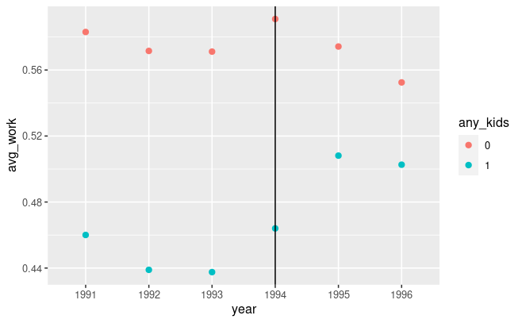

```r
names(new_eitc)[3] <- "avg_work"
new_eitc$any_kids <- as.factor(new_eitc$any_kids)
new_eitc$year <- as.factor(new_eitc$year)
ggplot(new_eitc, mapping = aes(x = year, y = avg_work, color = any_kids)) +
    geom_point(size = 2) +
    geom_vline(xintercept = "1994")
```

## 11. Based on the following model, run a regression to find the diff-in-diff estimate of the effect of the EITC on employment (work).

```r
m4 <- lm(work ~ after_1993 + any_kids + after_1993*any_kids, data = eitc)
summary(m4)
```

```
Call:
lm(formula = work ~ after_1993 + any_kids + after_1993 * any_kids,
    data = eitc)

Residuals:
    Min      1Q  Median      3Q     Max
-0.5755 -0.4908  0.4245  0.5092  0.5540

Coefficients:
                     Estimate Std. Error t value Pr(>|t|)
(Intercept)          0.575460   0.008845  65.060  < 2e-16 ***
after_1993          -0.002074   0.012931  -0.160  0.87261
any_kids            -0.129498   0.011676 -11.091  < 2e-16 ***
after_1993:any_kids  0.046873   0.017158   2.732  0.00631 **
---
Signif. codes:  0 ‘***’ 0.001 ‘**’ 0.01 ‘*’ 0.05 ‘.’ 0.1 ‘ ’ 1

Residual standard error: 0.4967 on 13742 degrees of freedom
Multiple R-squared:  0.0126,    Adjusted R-squared:  0.01238
F-statistic: 58.45 on 3 and 13742 DF,  p-value: < 2.2e-16
```

```r
stargazer(m4, type = 'text')
```

```
===============================================
                        Dependent variable:
                    ---------------------------
                               work
-----------------------------------------------
after_1993                    -0.002
                              (0.013)

any_kids                     -0.129***
                              (0.012)

after_1993:any_kids          0.047***
                              (0.017)

Constant                     0.575***
                              (0.009)

-----------------------------------------------
Observations                  13,746
R2                             0.013
Adjusted R2                    0.012
Residual Std. Error     0.497 (df = 13742)
F Statistic          58.451*** (df = 3; 13742)
===============================================
Note:               *p<0.1; **p<0.05; ***p<0.01
```

## 12. What is the difference-in-difference estimate? Discuss the result.

L’estimation “difference-in-difference” (after_1993:any_kids) est de 0.046873 (significatif à 1%). On observe donc une baisse du nombre de femmes sans emploi après l’arrivée de l’EITC. On peut en déduire que l’EITC a joué un role important dans la réduction du déséquilibre dans le travail.

## 13. Run a new regression model with demographic controls. Eissa and Liebman used the following in their original study: non-labor income (family income minus personal earnings, or the unearn column), number of children, race, age, age squared, education, and education squared.

```r
eitc$agesq <- eitc$age**2
eitc$edsq <- eitc$ed**2
m5 <- lm(work ~ unearn + children + nonwhite + age + agesq +ed + edsq + after_1993 + any_kids + after_1993 * any_kids, data = eitc)
summary(m5)
```

```
Call:
lm(formula = work ~ unearn + children + nonwhite + age + agesq +
    ed + edsq + after_1993 + any_kids + after_1993 * any_kids,
    data = eitc)

Residuals:
    Min      1Q  Median      3Q     Max
-0.7888 -0.4747  0.2414  0.4223  2.5168

Coefficients:
                      Estimate Std. Error t value Pr(>|t|)
(Intercept)          6.109e-02  5.996e-02   1.019 0.308263
unearn              -1.777e-02  5.763e-04 -30.841  < 2e-16 ***
children            -5.178e-02  4.519e-03 -11.458  < 2e-16 ***
nonwhite            -6.280e-02  8.482e-03  -7.404  1.4e-13 ***
age                  3.010e-02  3.265e-03   9.217  < 2e-16 ***
agesq               -3.769e-04  4.491e-05  -8.392  < 2e-16 ***
ed                  -3.983e-03  5.951e-03  -0.669 0.503368
edsq                 1.415e-03  4.339e-04   3.262 0.001110 **
after_1993          -8.675e-03  1.233e-02  -0.704 0.481618
any_kids            -2.103e-02  1.467e-02  -1.433 0.151861
after_1993:any_kids  5.812e-02  1.636e-02   3.554 0.000381 ***
---
Signif. codes:  0 ‘***’ 0.001 ‘**’ 0.01 ‘*’ 0.05 ‘.’ 0.1 ‘ ’ 1

Residual standard error: 0.4733 on 13735 degrees of freedom
Multiple R-squared:  0.1041,    Adjusted R-squared:  0.1035
F-statistic: 159.7 on 10 and 13735 DF,  p-value: < 2.2e-16
```

```r
stargazer(m5, type = 'text')
```

```
===============================================
                        Dependent variable:
                    ---------------------------
                               work
-----------------------------------------------
unearn                       -0.018***
                              (0.001)

children                     -0.052***
                              (0.005)

nonwhite                     -0.063***
                              (0.008)

age                          0.030***
                              (0.003)

agesq                       -0.0004***
                             (0.00004)

ed                            -0.004
                              (0.006)

edsq                         0.001***
                             (0.0004)

after_1993                    -0.009
                              (0.012)

any_kids                      -0.021
                              (0.015)

after_1993:any_kids          0.058***
                              (0.016)

Constant                       0.061
                              (0.060)

-----------------------------------------------
Observations                  13,746
R2                             0.104
Adjusted R2                    0.103
Residual Std. Error     0.473 (df = 13735)
F Statistic         159.668*** (df = 10; 13735)
===============================================
Note:               *p<0.1; **p<0.05; ***p<0.01
```

## 14. Does the treatment effect change? Interpret these findings.

Oui on peut voir un changement, en effet after_1993:any_kids est passé de 0.046873 a 0.05812 ce qui signifie que l’impact démographique est significatif en ce qui concerne l’accès à l’EITC.

## 15. Make two new binary indicator variables showing if the woman has one child or not and two children or not. Name them one_kid and two_plus_kids.

```r
eitc <- eitc %>%
  mutate(one_kid = ifelse(
    children == 1, 1, 0))
eitc <- eitc %>%
  mutate(two_plus_kids = ifelse(
    children == 2, 1, 0))
```

## 16. Rerun the regression model with all the demographic controls, but remove the any_kids and any_kids * after_1993 terms and replace them with two new interaction terms: one_kid * after_1993 and two_plus_kids * after_1993. For which group of women is the EITC treatment the strongest for (i.e. which group sees the greatest change in employment)? Why do you think that is?

```r
m6 <- lm(work ~ unearn + children + nonwhite + age + agesq +ed + edsq + after_1993 + one_kid + two_plus_kids + one_kid * after_1993 + two_plus_kids * after_1993, data = eitc)
summary(m6)
```

```
Call:
lm(formula = work ~ unearn + children + nonwhite + age + agesq +
    ed + edsq + after_1993 + one_kid + two_plus_kids + one_kid *
    after_1993 + two_plus_kids * after_1993, data = eitc)

Residuals:
    Min      1Q  Median      3Q     Max
-0.7915 -0.4762  0.2442  0.4218  2.5031

Coefficients:
                           Estimate Std. Error t value Pr(>|t|)
(Intercept)               5.351e-02  5.997e-02   0.892  0.37224
unearn                   -1.775e-02  5.765e-04 -30.798  < 2e-16 ***
children                 -5.085e-02  3.264e-03 -15.577  < 2e-16 ***
nonwhite                 -6.254e-02  8.484e-03  -7.372 1.78e-13 ***
age                       2.984e-02  3.266e-03   9.137  < 2e-16 ***
agesq                    -3.733e-04  4.492e-05  -8.310  < 2e-16 ***
ed                       -4.016e-03  5.955e-03  -0.674  0.50010
edsq                      1.416e-03  4.342e-04   3.261  0.00111 **
after_1993                1.451e-02  1.043e-02   1.391  0.16418
one_kid                  -4.509e-03  1.371e-02  -0.329  0.74232
two_plus_kids            -2.945e-03  1.524e-02  -0.193  0.84680
after_1993:one_kid        2.058e-02  2.010e-02   1.024  0.30604
after_1993:two_plus_kids  3.020e-02  2.205e-02   1.369  0.17089
---
Signif. codes:  0 ‘***’ 0.001 ‘**’ 0.01 ‘*’ 0.05 ‘.’ 0.1 ‘ ’ 1

Residual standard error: 0.4735 on 13733 degrees of freedom
Multiple R-squared:  0.1035,    Adjusted R-squared:  0.1027
F-statistic: 132.2 on 12 and 13733 DF,  p-value: < 2.2e-16
```

```r
stargazer(m6, type = 'text')
```

```
====================================================
                             Dependent variable:
                         ---------------------------
                                    work
----------------------------------------------------
unearn                            -0.018***
                                   (0.001)

children                          -0.051***
                                   (0.003)

nonwhite                          -0.063***
                                   (0.008)

age                               0.030***
                                   (0.003)

agesq                            -0.0004***
                                  (0.00004)

ed                                 -0.004
                                   (0.006)

edsq                              0.001***
                                  (0.0004)

after_1993                          0.015
                                   (0.010)

one_kid                            -0.005
                                   (0.014)

two_plus_kids                      -0.003
                                   (0.015)

after_1993:one_kid                  0.021
                                   (0.020)

after_1993:two_plus_kids            0.030
                                   (0.022)

Constant                            0.054
                                   (0.060)

----------------------------------------------------
Observations                       13,746
R2                                  0.104
Adjusted R2                         0.103
Residual Std. Error          0.473 (df = 13733)
F Statistic              132.155*** (df = 12; 13733)
====================================================
Note:                    *p<0.1; **p<0.05; ***p<0.01
```

## 17. To make sure this effect isn’t driven by any pre-treatment trends, we can pretend that the EITC was expanded in 1991 (starting in 1992) instead of 1993. Create a new dataset that only includes data from 1991–1993. Create a new binary before/after indicator named after_1991. Use regression to find the diff-in-diff estimate of the EITC on work.

```r
years_filtered <- c("1991","1992","1993")
eitc <- eitc %>%
    filter(year %in% years_filtered)
eitc <- eitc %>%
  mutate(after_1991 = ifelse( year > "1991", 1, 0))
```

```r
m7 <- lm(work ~ after_1991 * one_kid + after_1991 * two_plus_kids + unearn + children + nonwhite + age + agesq +ed + edsq, data = eitc)
summary(m7)
```

```
Call:
lm(formula = work ~ after_1991 * one_kid + after_1991 * two_plus_kids +
    unearn + children + nonwhite + age + agesq + ed + edsq, data = eitc)

Residuals:
    Min      1Q  Median      3Q     Max
-0.8008 -0.4656  0.2161  0.4258  2.3524

Coefficients:
                           Estimate Std. Error t value Pr(>|t|)
(Intercept)               0.1075406  0.0828075   1.299   0.1941
after_1991               -0.0171627  0.0148130  -1.159   0.2466
one_kid                   0.0004473  0.0227701   0.020   0.9843
two_plus_kids             0.0009545  0.0258748   0.037   0.9706
unearn                   -0.0181970  0.0007972 -22.827  < 2e-16 ***
children                 -0.0600194  0.0044687 -13.431  < 2e-16 ***
nonwhite                 -0.0548905  0.0114318  -4.802 1.61e-06 ***
age                       0.0298942  0.0045042   6.637 3.43e-11 ***
agesq                    -0.0003714  0.0000619  -6.000 2.07e-09 ***
ed                       -0.0182212  0.0080559  -2.262   0.0237 *
edsq                      0.0024167  0.0005890   4.103 4.12e-05 ***
after_1991:one_kid       -0.0070041  0.0283500  -0.247   0.8049
after_1991:two_plus_kids  0.0095066  0.0313977   0.303   0.7621
---
Signif. codes:  0 ‘***’ 0.001 ‘**’ 0.01 ‘*’ 0.05 ‘.’ 0.1 ‘ ’ 1

Residual standard error: 0.472 on 7388 degrees of freedom
Multiple R-squared:  0.1103,    Adjusted R-squared:  0.1088
F-statistic: 76.29 on 12 and 7388 DF,  p-value: < 2.2e-16
```

```r
stargazer(m7, type="text")
```

```
====================================================
                             Dependent variable:
                         ---------------------------
                                    work
----------------------------------------------------
after_1991                         -0.017
                                   (0.015)

one_kid                            0.0004
                                   (0.023)

two_plus_kids                       0.001
                                   (0.026)

unearn                            -0.018***
                                   (0.001)

children                          -0.060***
                                   (0.004)

nonwhite                          -0.055***
                                   (0.011)

age                               0.030***
                                   (0.005)

agesq                            -0.0004***
                                  (0.0001)

ed                                -0.018**
                                   (0.008)

edsq                              0.002***
                                   (0.001)

after_1991:one_kid                 -0.007
                                   (0.028)

after_1991:two_plus_kids            0.010
                                   (0.031)

Constant                            0.108
                                   (0.083)

----------------------------------------------------
Observations                        7,401
R2                                  0.110
Adjusted R2                         0.109
Residual Std. Error           0.472 (df = 7388)
F Statistic               76.288*** (df = 12; 7388)
====================================================
Note:                    *p<0.1; **p<0.05; ***p<0.01
```

## 18. Is there a significant effect? What does this mean for pre-treatment trends?

Nous n’observons aucun effet significatif. Cela signifie qu’il n’y a pas d’effet de tendances avant 1993.